# Assignment1

### Population of the data set are the origins

### Samples are the varieties

### Observations are the Flavor/aroma, fragrance,mouth feel,aftertaste ,overall ,salt/acid,bitter/sweet ,balance, uniformity ,clean cups

### Research question :Does performance of varieties vary in different districts ?

### Null Hypothesis:performance of varieties varies in different districts

### Alternative Hypothesis:performance of varieties doesnot vary in different districts

## **1.Descriptive Statistics**

- Calculate the mode of the overall #### Mode

```
## [1] 7.5
```

variance and Standard deviation for overall respectively

```
## [1] NA
```

```
## [1] NA
```

## Summary of performance in the different regions

- Ibanda summary statistics

```
##    Min. 1st Qu.  Median    Mean 3rd Qu.    Max.
##    6.75    7.25    7.50    7.59    8.00    8.75
```

- Mityana summary statistics

```
##    Min. 1st Qu.  Median    Mean 3rd Qu.    Max.
##   6.000   7.000   7.500   7.402   7.750   8.750
```

- Mukono summary statistics

```
##    Min. 1st Qu.  Median    Mean 3rd Qu.    Max.
##   6.500   7.250   7.500   7.524   7.750   9.000
```

- Visualise the distribution of the overall across the different districts
- We can see the histogram for Ibanda is positively skewed

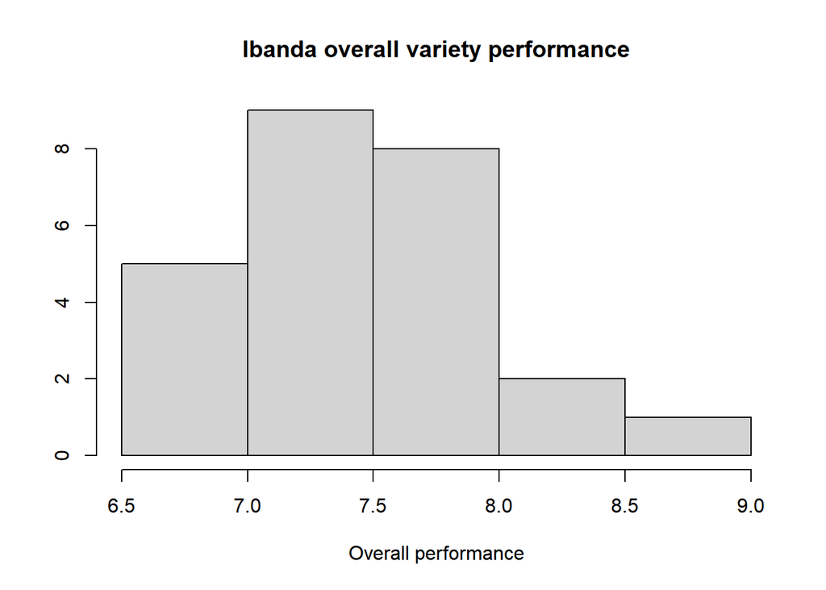

- Mityana is negatively skewed

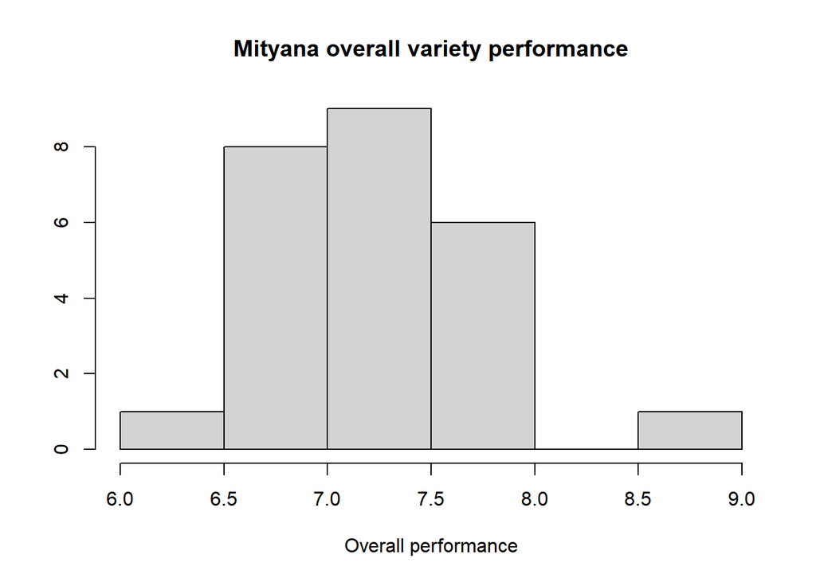

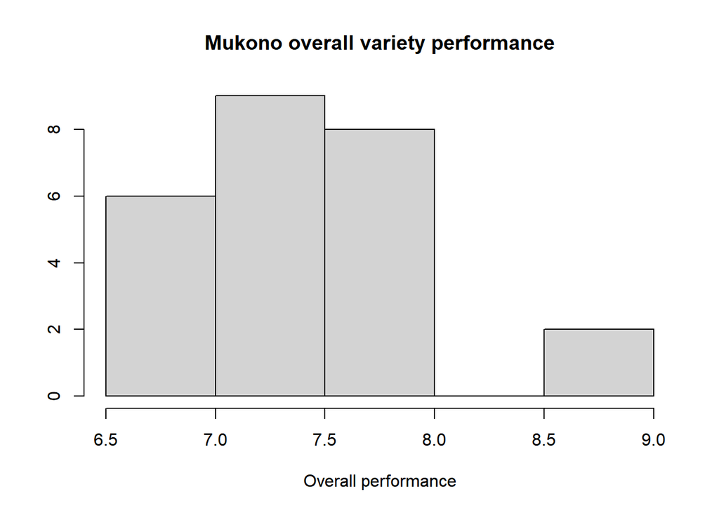

- The histogram for Mukono is positively skewed

## **2.Showing the relationships between the variables**

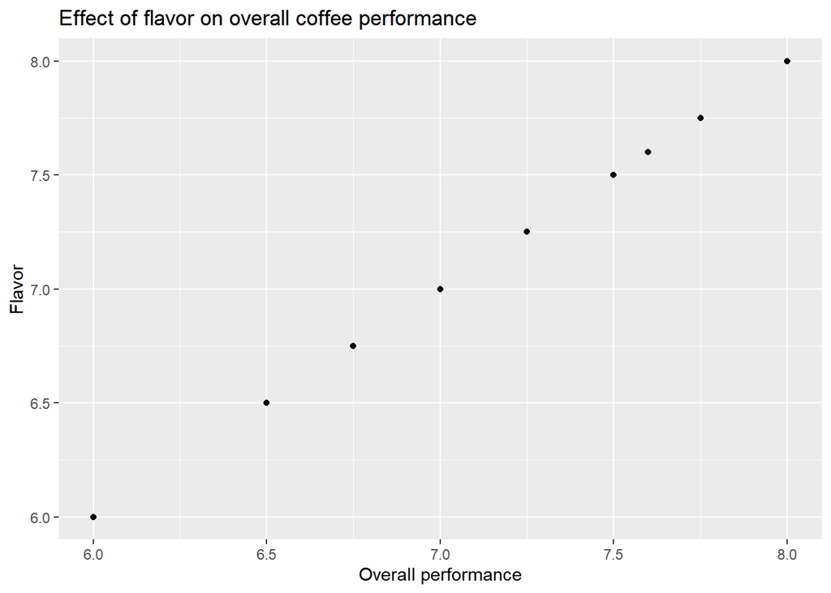

[figure not shown]

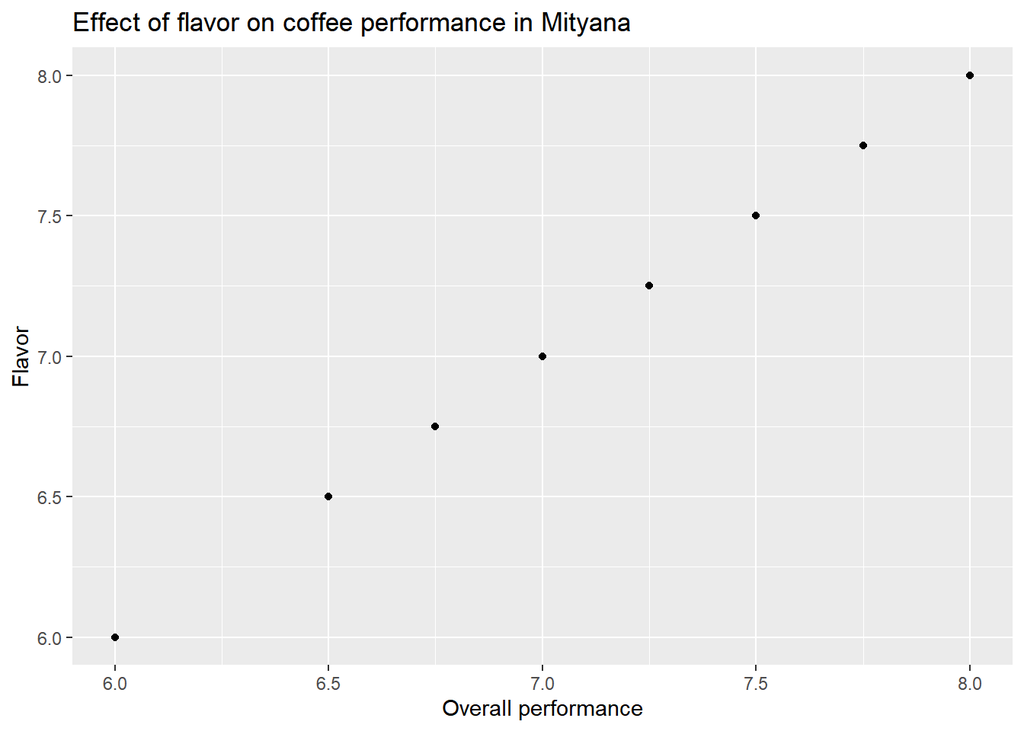

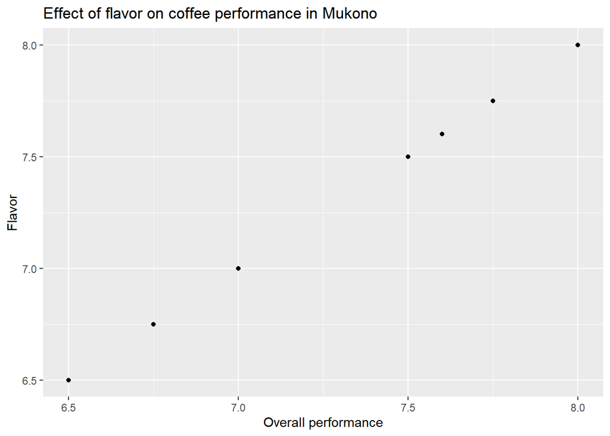

## **3. PERFORMANCE BY VARIETY AND DISTRICT**

**Across districts;** *Compute medians of districts to show performance since Medians are most suitable rather than the means which were skewed*

*IBANDA MEAN*

```r
Ibanda_mean <- mean(Ibanda$OVERALL)
string1<-"Ibanda overall mean is"
result1=paste(string1,Ibanda_mean)
print(result1)
```

```
## [1] "Ibanda overall mean is 7.59"
```

*MITYANA MEAN*

```r
Mityana_mean <- mean(Mityana$OVERALL)
string2<-"Mityana overall mean is"
result2=paste(string2,Mityana_mean)
print(result2)
```

```
## [1] "Mityana overall mean is 7.4024"
```

*MUKONO MEAN*

```r
Mukono_mean <- mean(Mukono$OVERALL)
string3<-"Mukono overall mean is"
result3=paste(string3,Mukono_mean)
print(result3)
```

```
## [1] "Mukono overall mean is 7.524"
```

```r
Ibanda_median <- median(Ibanda$OVERALL)
ibanda1<-"Ibanda overall median is"
result4=paste(ibanda1,Ibanda_median)
print(result4)
```

```
## [1] "Ibanda overall median is 7.5"
```

```r
Mityana_median <- median(Mityana$OVERALL)
Mityana1<-"Mityana overall median is"
result5=paste(Mityana1,Mityana_median)
print(result5)
```

```
## [1] "Mityana overall median is 7.5"
```

```r
Mukono_median <- median(Mukono$OVERALL)
Mukono1<-"Mukono overall median is"
result6=paste(Mukono1,Mukono_median)
print(result6)
```

```
## [1] "Mukono overall median is 7.5"
```

**Combine the districts, means or medians**

```r
Districts <- c("Ibanda", "Mityana", "Mukono")
Means <- c(Ibanda_mean, Mityana_mean, Mukono_mean)
```

*OR*

```r
Median <- c(Ibanda_median, Mityana_median, Mukono_median)
```

**Make a dataframe of the districts and means**

```r
Districts_means <- data.frame(Districts,Means)
```

**OR: Make a dataframe of the districts and medians**

```r
Districts_medians <- data.frame(Districts,Median)
```

*A Plot of the results*

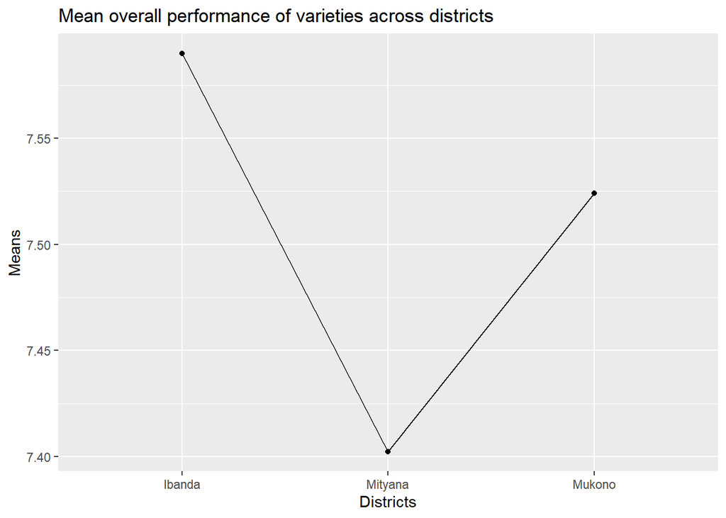

```r
ggplot(Districts_means, aes(Districts,Means,group=1)) +
  geom_line() + geom_point() + labs(title = "Mean overall performance of varieties across districts")
```

**OR Using median** ggplot(Districts_medians, aes(Districts, Median,group=1)) + geom_line() + geom_point() + labs(title = “Median overall performance of varieties across districts”)

### **Performance of each variety**

*Transform the dataset to subselect varieties individually*

```r
KR3 <- dataset[dataset$VARIETY == "KR3",]
KR4 <- dataset[dataset$VARIETY == "KR4",]
KR5 <- dataset[dataset$VARIETY == "KR5",]
KR6 <- dataset[dataset$VARIETY == "KR6",]
KR7 <- dataset[dataset$VARIETY == "KR7",]
```

**Compute overall means of each variety**

```r
mean_KR3 <- mean(KR3$OVERALL)
mean_KR4 <- mean(KR4$OVERALL)
mean_KR5 <- mean(KR5$OVERALL)
mean_KR6 <- mean(KR6$OVERALL)
mean_KR7 <- mean(KR7$OVERALL)
```

### OR

**Compute overall medians of each variety**

```r
median_KR3 <- median(KR3$OVERALL)
median_KR4 <- median(KR4$OVERALL)
median_KR5 <- median(KR5$OVERALL)
median_KR6 <- median(KR6$OVERALL)
median_KR7 <- median(KR7$OVERALL)
```

**Combine the varieties, means or medians**

```r
Varieties <- c("KR3", "KR4", "KR5", "KR6", "KR7")
Variety_means <- c(mean_KR3,mean_KR4,mean_KR5,mean_KR6,mean_KR7)
Variety_median <- c(median_KR3, median_KR4, median_KR5, median_KR6, median_KR7)
```

**Create a dataframe of Varieties and Variety_means**

```r
Dataframe_1 <- data.frame(Varieties, Variety_means)
```

### OR

**Create a datframe of Varieties and Variety_median**

```r
Dataframe_2 <- data.frame(Varieties, Variety_median)
```

*A Plot of the results*

[figure not shown]

```r
ggplot(Dataframe_1, aes(Varieties, Variety_means, group=1)) +
  geom_line() + geom_point() + labs (title = "Mean overall variety performance")
```

## **4. CENTRAL TENDENCY/DISTRIBUTION OF EACH VARIABLE.**

### Using a boxplot

**Distribution of overall**

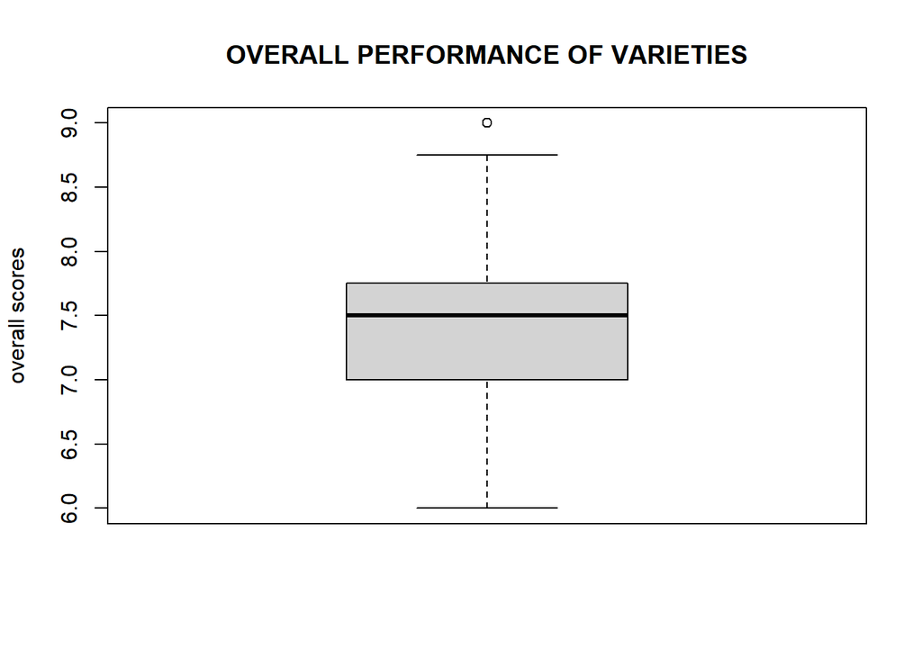

```r
boxplot(dataset$OVERALL, main = "OVERALL PERFORMANCE OF VARIETIES", ylab = "overall scores")
```

## **QUESTION 5: NORMAL DISTRIBUTION TESTS**

*Test the overall variable for normal distribution using the Shapiro-wilk test* *Null hypothesis based on research question: The overall performance of varieties across* *districts is normally distributed. p-value >= 0.05* *Alternative hypothesis: Overall performance is not normally distributed across districts. p-value =<0.05*

```r
shapiro.test(dataset$OVERALL)
```

```
##
##  Shapiro-Wilk normality test
##
## data:  dataset$OVERALL
## W = 0.95674, p-value = 0.01189
```

*W = 0.95674, p-value = 0.01189*

*The data is not normally distributed, it’s recommended to use the non parametric one-sample Wilcoxon rank test.* **WILCOXON ONE-SAMPLE TEST** *The one-sample Wilcoxon signed rank test is a non-parametric alternative to one-sample t-test when the data cannot be assumed to be normally distributed.* *it is Used to determine whether the median of the sample is equal to a known standard value (i.e. theoretical value).* **Looking at the article m =0.8**

```r
res <- wilcox.test(dataset$OVERALL, mu = 0.8)
res
```

```
##
##  Wilcoxon signed rank test with continuity correction
##
## data:  dataset$OVERALL
## V = 2850, p-value = 4.371e-14
## alternative hypothesis: true location is not equal to 0.8
```